# Modeling_Results

Ekin Kizildas

2025-06-15

## Packages

```r
library(tidyverse)
library(MASS)
library(pscl)
library(car)
library(broom)
library(modelsummary)
library(flextable)
```

```r
library(officer)
library(corrplot)
library(knitr)
library(kableExtra)
```

Prior to modeling, the cleaned and preprocessed dataset is loaded using the following command:

```r
source("extracted_data_cleaning_code.R", local = knitr::knit_global())
```

```
## ──────────────────────────────────────────────────────── Delimiter: "," chr
## (9): asin, text, title.x, parent_asin, user_id, main_category, title.y, ... dbl
## (7): ...1, rating, helpful_vote, timestamp, average_rating, rating_numbe... lgl
## (1): verified_purchase
```

## 5. Correlation Matrix

A correlation matrix is computed to examine the linear relationships between key numerical variables, including review characteristics (e.g., length, rating, age, price) and sentiment scores derived from both lexicon-based methods (e.g., AFINN, BING) and emotion dimensions (e.g., joy, trust, anger).

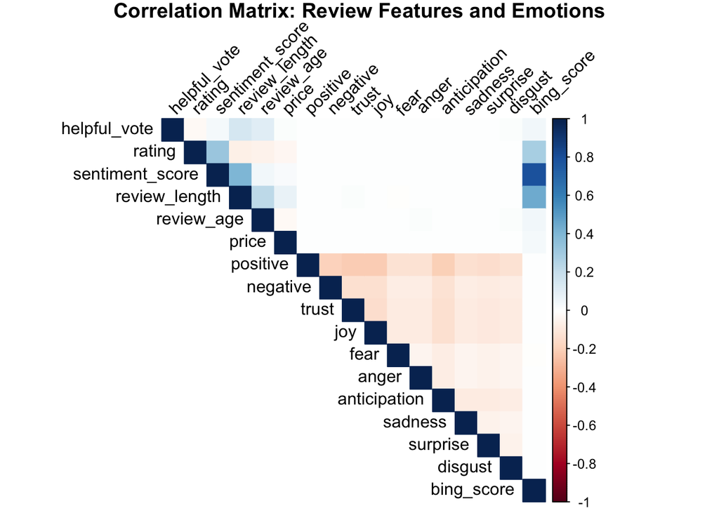

```r
corr <- sample_data %>%
  dplyr::select(
    helpful_vote, rating, sentiment_score, review_length, review_age, price,
    positive, negative, trust, joy, fear, anger, anticipation, sadness, surprise, disgust, bing_score
  ) %>%
  cor(use = "complete.obs") %>%
  round(2)


corrplot(corr, method = "color", type = "upper",
         tl.col = "black", tl.srt = 45,
         title = "Correlation Matrix: Review Features and Emotions",
         mar = c(0, 0, 1, 0))
```

## Modeling part

To prepare the data for modeling, the verified_purchase variable is converted to a factor to ensure proper treatment as a categorical predictor in regression models. Additionally, all continuous predictors are standardized (z-scores) to facilitate interpretation and allow for meaningful comparison of coefficients across different scales.

```r
# Converting verified_purchase to factor
sample_data$verified_purchase <- as.factor(sample_data$verified_purchase)

# Standardizing data
standardized_data <- sample_data %>%
  mutate(across(
    c(sentiment_score, review_length, rating, price, review_age, bing_score,
      joy, trust, fear, anger, sadness, disgust, surprise, anticipation),
    ~ scale(.) %>% as.numeric()
  ))
```

### Model1

This baseline Negative Binomial model predicts the number of helpful votes a review receives based on verified purchase status, sentiment scores (AFINN and BING), review length, star rating, review age, price, and product category. It serves to evaluate how both emotional tone and contextual features shape perceived helpfulness, while accounting for overdispersion in the count data.

```r
model1 <- glm.nb(helpful_vote ~
                     verified_purchase + sentiment_score + bing_score + review_length +
                     rating + review_age + price + category ,
                   data = standardized_data)

summary(model1)
```

```
##
## Call:
## glm.nb(formula = helpful_vote ~ verified_purchase + sentiment_score +
##     bing_score + review_length + rating + review_age + price +
##     category, data = standardized_data, init.theta = 0.2011727272,
##     link = log)
##
## Coefficients:
##                               Estimate Std. Error z value Pr(>|z|)
## (Intercept)                   0.067132   0.019024   3.529 0.000417 ***
## verified_purchaseTRUE         0.555025   0.013654  40.650  < 2e-16 ***
## sentiment_score               0.085479   0.010346   8.262  < 2e-16 ***
## bing_score                   -0.035872   0.010341  -3.469 0.000523 ***
## review_length                 0.764526   0.007123 107.335  < 2e-16 ***
## rating                       -0.183829   0.007023 -26.175  < 2e-16 ***
## review_age                    0.393924   0.006723  58.589  < 2e-16 ***
## price                         0.060288   0.005854  10.298  < 2e-16 ***
## categoryBeauty               -0.381699   0.025669 -14.870  < 2e-16 ***
## categoryBeauty_Personal_Care -0.358495   0.025534 -14.040  < 2e-16 ***
## categoryBooks                -0.417790   0.025783 -16.204  < 2e-16 ***
## categoryElectronics          -0.518251   0.025472 -20.346  < 2e-16 ***
## categoryFashion              -0.805800   0.026617 -30.274  < 2e-16 ***
## categoryPet_Supplies         -0.375109   0.025402 -14.767  < 2e-16 ***
## categorySoftware              0.870221   0.025223  34.502  < 2e-16 ***
## ---
## Signif. codes:  0 '***' 0.001 '**' 0.01 '*' 0.05 '.' 0.1 ' ' 1
##
## (Dispersion parameter for Negative Binomial(0.2012) family taken to be 1)
##
##     Null deviance: 135185  on 152212  degrees of freedom
## Residual deviance: 102393  on 152198  degrees of freedom
##   (7787 observations deleted due to missingness)
## AIC: 397688
##
## Number of Fisher Scoring iterations: 1
##
##
##               Theta:  0.20117
##           Std. Err.:  0.00125
##
##  2 x log-likelihood:  -397655.87200
```

```r
# Making a table
tidy(model1) %>%
  mutate(signif = case_when(
    p.value < 0.001 ~ "***",
    p.value < 0.01 ~ "**",
    p.value < 0.05 ~ "*",
    TRUE ~ ""
  )) %>%
 dplyr::select(term, estimate, std.error, statistic, signif) %>%
  mutate(across(where(is.numeric), ~round(., 3))) %>%
  flextable() %>%
  font(fontname = "Times New Roman", part = "all")
```

| term | estimate | std.error | statistic | signif |
| --- | --- | --- | --- | --- |
| (Intercept) | 0.067 | 0.019 | 3.529 | *** |
| verified_purchaseTRUE | 0.555 | 0.014 | 40.650 | *** |
| sentiment_score | 0.085 | 0.010 | 8.262 | *** |
| bing_score | -0.036 | 0.010 | -3.469 | *** |
| review_length | 0.765 | 0.007 | 107.335 | *** |
| rating | -0.184 | 0.007 | -26.175 | *** |
| review_age | 0.394 | 0.007 | 58.589 | *** |
| price | 0.060 | 0.006 | 10.298 | *** |
| categoryBeauty | -0.382 | 0.026 | -14.870 | *** |
| categoryBeauty_Personal_Care | -0.358 | 0.026 | -14.040 | *** |
| categoryBooks | -0.418 | 0.026 | -16.204 | *** |
| categoryElectronics | -0.518 | 0.025 | -20.346 | *** |
| categoryFashion | -0.806 | 0.027 | -30.274 | *** |
| categoryPet_Supplies | -0.375 | 0.025 | -14.767 | *** |
| categorySoftware | 0.870 | 0.025 | 34.502 | *** |

This code produces a clean summary table of the baseline Negative Binomial model using the modelsummary package. It displays the estimated coefficients alongside their standard errors, rounds values to three decimal places, and uses stars to indicate statistical significance. The output is formatted as a flextable for seamless export to Word or PDF.

```r
modelsummary(model1,
             fmt = 3,
             statistic = "std.error",
             stars = TRUE,
             output = "flextable")
```

|  | (1) |
| --- | --- |
| (Intercept) | 0.067*** |
|  | (0.019) |
| verified_purchaseTRUE | 0.555*** |
|  | (0.014) |
| sentiment_score | 0.085*** |
|  | (0.010) |
| bing_score | -0.036*** |
|  | (0.010) |
| review_length | 0.765*** |
|  | (0.007) |
| rating | -0.184*** |
|  | (0.007) |
| review_age | 0.394*** |
|  | (0.007) |
| price | 0.060*** |
|  | (0.006) |
| categoryBeauty | -0.382*** |
|  | (0.026) |
| categoryBeauty_Personal_Care | -0.358*** |
|  | (0.026) |
| categoryBooks | -0.418*** |
|  | (0.026) |
| categoryElectronics | -0.518*** |
|  | (0.025) |
| categoryFashion | -0.806*** |
|  | (0.027) |
| categoryPet_Supplies | -0.375*** |
|  | (0.025) |
| categorySoftware | 0.870*** |
|  | (0.025) |
| Num.Obs. | 152213 |
| AIC | 397687.9 |
| BIC | 397846.8 |
| Log.Lik. | -198827.936 |
| F | 2420.418 |
| RMSE | 1.7e+13 |

+ p < 0.1, * p < 0.05, ** p < 0.01, *** p < 0.001

### Model 2

This model extends the baseline Negative Binomial regression by incorporating two interaction terms: one between verified purchase status and sentiment score, and another between verified status and BING sentiment score. These interactions aim to capture whether the effect of sentiment on helpfulness varies depending on whether the reviewer is verified. Other variables like rating, review length, age, price, and product category are included as controls.

```r
# Negative Binomial with interaction
model2 <- glm.nb(helpful_vote ~
                                 verified_purchase * sentiment_score + verified_purchase * bing_score +
                                 rating + review_length + review_age + price + category,
                               data = standardized_data)


model2
```

```
##
## Call:  glm.nb(formula = helpful_vote ~ verified_purchase * sentiment_score +
##     verified_purchase * bing_score + rating + review_length +
##     review_age + price + category, data = standardized_data,
##     init.theta = 0.2028132646, link = log)
##
## Coefficients:
##                           (Intercept)                  verified_purchaseTRUE
##                               0.06032                                0.57060
##                       sentiment_score                             bing_score
##                               0.03063                               -0.07850
##                                rating                          review_length
##                              -0.18444                                0.77769
##                            review_age                                  price
##                               0.38784                                0.05888
##                        categoryBeauty           categoryBeauty_Personal_Care
##                              -0.35917                               -0.33652
##                         categoryBooks                    categoryElectronics
##                              -0.40920                               -0.49046
##                       categoryFashion                   categoryPet_Supplies
##                              -0.77910                               -0.34003
##                      categorySoftware  verified_purchaseTRUE:sentiment_score
##                               0.91216                                0.14771
##      verified_purchaseTRUE:bing_score
##                               0.19161
##
## Degrees of Freedom: 152212 Total (i.e. Null);  152196 Residual
##   (7787 observations deleted due to missingness)
## Null Deviance:       136000
## Residual Deviance: 102500    AIC: 397200
```

```r
tidy(model2) %>%
  mutate(signif = case_when(
    p.value < 0.001 ~ "***",
    p.value < 0.01 ~ "**",
    p.value < 0.05 ~ "*",
    TRUE ~ ""
  )) %>%
 dplyr::select(term, estimate, std.error, statistic, signif) %>%
  mutate(across(where(is.numeric), ~round(., 3))) %>%
  flextable() %>%
  font(fontname = "Times New Roman", part = "all")
```

| term | estimate | std.error | statistic | signif |
| --- | --- | --- | --- | --- |
| (Intercept) | 0.060 | 0.019 | 3.174 |  |
| verified_purchaseTRUE | 0.571 | 0.014 | 41.435 | *** |
| sentiment_score | 0.031 | 0.012 | 2.568 |  |
| bing_score | -0.079 | 0.012 | -6.765 | *** |
| rating | -0.184 | 0.007 | -26.259 | *** |
| review_length | 0.778 | 0.007 | 109.391 | *** |
| review_age | 0.388 | 0.007 | 57.797 | *** |
| price | 0.059 | 0.006 | 10.089 | *** |
| categoryBeauty | -0.359 | 0.026 | -14.013 | *** |
| categoryBeauty_Personal_Care | -0.337 | 0.026 | -13.196 | *** |
| categoryBooks | -0.409 | 0.026 | -15.893 | *** |
| categoryElectronics | -0.490 | 0.025 | -19.293 | *** |
| categoryFashion | -0.779 | 0.027 | -29.307 | *** |
| categoryPet_Supplies | -0.340 | 0.025 | -13.416 | *** |
| categorySoftware | 0.912 | 0.025 | 36.247 | *** |
| verified_purchaseTRUE:sentiment_score | 0.148 | 0.022 | 6.580 | *** |
| verified_purchaseTRUE:bing_score | 0.192 | 0.024 | 7.863 | *** |

```r
modelsummary(model2,
             fmt = 3,
             statistic = "std.error",
             stars = TRUE,
             output = "flextable")
```

|  | (1) |
| --- | --- |
| (Intercept) | 0.060** |
|  | (0.019) |
| verified_purchaseTRUE | 0.571*** |
|  | (0.014) |
| sentiment_score | 0.031* |
|  | (0.012) |
| bing_score | -0.079*** |
|  | (0.012) |
| rating | -0.184*** |
|  | (0.007) |
| review_length | 0.778*** |
|  | (0.007) |
| review_age | 0.388*** |
|  | (0.007) |
| price | 0.059*** |
|  | (0.006) |
| categoryBeauty | -0.359*** |
|  | (0.026) |
| categoryBeauty_Personal_Care | -0.337*** |
|  | (0.026) |
| categoryBooks | -0.409*** |
|  | (0.026) |
| categoryElectronics | -0.490*** |
|  | (0.025) |
| categoryFashion | -0.779*** |
|  | (0.027) |
| categoryPet_Supplies | -0.340*** |
|  | (0.025) |
| categorySoftware | 0.912*** |
|  | (0.025) |
| verified_purchaseTRUE × sentiment_score | 0.148*** |
|  | (0.022) |
| verified_purchaseTRUE × bing_score | 0.192*** |
|  | (0.024) |
| Num.Obs. | 152213 |
| AIC | 397212.8 |
| BIC | 397391.6 |
| Log.Lik. | -198588.405 |
| F | 2154.803 |
| RMSE | 1.9e+13 |

+ p < 0.1, * p < 0.05, ** p < 0.01, *** p < 0.001

### Model 3

This model includes eight NRC emotion scores as key predictors to assess how specific emotional tones influence helpfulness votes. Alongside these, verified purchase, review length, review age, price, and category are included as control variables. The aim is to evaluate the direct contribution of each emotional dimension to review helpfulness using a Negative Binomial regression framework.

```r
model3 <- glm.nb(helpful_vote ~ joy + trust + fear + anger + sadness + disgust + surprise + anticipation + verified_purchase + review_length + review_age + price + category,
                               data = standardized_data)



model3
```

```
##
## Call:  glm.nb(formula = helpful_vote ~ joy + trust + fear + anger +
##     sadness + disgust + surprise + anticipation + verified_purchase +
##     review_length + review_age + price + category, data = standardized_data,
##     init.theta = 0.1960947293, link = log)
##
## Coefficients:
##                  (Intercept)                           joy
##                    0.1169103                    -0.0104197
##                        trust                          fear
##                    0.0217310                    -0.0053118
##                        anger                       sadness
##                   -0.0200357                    -0.0018587
##                      disgust                      surprise
##                   -0.0009861                     0.0131136
##                 anticipation         verified_purchaseTRUE
##                    0.0112529                     0.4672090
##                review_length                    review_age
##                    0.8071279                     0.3924438
##                        price                categoryBeauty
##                    0.0693311                    -0.4008478
## categoryBeauty_Personal_Care                 categoryBooks
##                   -0.3795214                    -0.4407589
##          categoryElectronics               categoryFashion
##                   -0.5554571                    -0.8127846
##         categoryPet_Supplies              categorySoftware
##                   -0.4118171                     0.9263646
##
## Degrees of Freedom: 159999 Total (i.e. Null);  159980 Residual
## Null Deviance:       139100
## Residual Deviance: 106300    AIC: 412200
```

```r
ft_nrc <- modelsummary(
  model3,
  fmt = 3,                         # 3 ondalık basamak
  statistic = "std.error",         # yalnızca std.error göster
  stars = TRUE,                    # p-value'lara göre yıldız
  output = "flextable"
) %>%
  fontsize(size = 10, part = "all") %>%
  padding(padding = 2, part = "all") %>%
  align(align = "center", part = "all") %>%
  set_table_properties(width = 0.95, layout = "autofit") %>%
  font(fontname = "Times New Roman", part = "all")

doc <- read_docx() %>%
  body_add_par("Table A2. Standardized Coefficients from NRC Emotion-Enriched Negative Binomial Model", style = "heading 2") %>%
  body_add_flextable(ft_nrc) %>%
  body_add_par("Note: All continuous predictors are z-standardized. Standard errors in parentheses. + p < 0.1, * p < 0.05, ** p < 0.01, *** p < 0.001", style = "Normal")

# 3. Dışa aktar
print(doc, target = "Table_B3_NRC_Model.docx")
```

### Model4-Emotion × Verified Purchase Interaction

Model 4 examines how emotional expressions interact with the reviewer’s verified purchase status in shaping perceived helpfulness. Specifically, it includes interaction terms between eight NRC emotions and whether the reviewer is verified. Control variables such as review length, rating, review age, price, and product category are also included. This setup allows the model to test whether emotional tone influences helpfulness differently for verified and non-verified reviewers.

```r
model4 <- glm.nb(helpful_vote ~
                                joy * verified_purchase +
                                trust * verified_purchase +
                                fear * verified_purchase +
                                anger * verified_purchase +
                                sadness * verified_purchase +
                                disgust * verified_purchase +
                                surprise * verified_purchase +
                                anticipation * verified_purchase +
                                review_length + rating + review_age + price + category,
                              data = standardized_data)

summary(model4)
```

```
##
## Call:
## glm.nb(formula = helpful_vote ~ joy * verified_purchase + trust *
##     verified_purchase + fear * verified_purchase + anger * verified_purchase +
##     sadness * verified_purchase + disgust * verified_purchase +
##     surprise * verified_purchase + anticipation * verified_purchase +
##     review_length + rating + review_age + price + category, data = standardized_data,
##     init.theta = 0.1983671362, link = log)
##
## Coefficients:
##                                      Estimate Std. Error z value Pr(>|z|)
## (Intercept)                         0.0277980  0.0186743   1.489 0.136599
## joy                                -0.0091640  0.0097333  -0.942 0.346443
## verified_purchaseTRUE               0.5185776  0.0133565  38.826  < 2e-16 ***
## trust                               0.0055482  0.0096793   0.573 0.566511
## fear                                0.0097638  0.0093731   1.042 0.297560
## anger                               0.0006885  0.0092779   0.074 0.940848
## sadness                             0.0019012  0.0093768   0.203 0.839324
## disgust                             0.0073533  0.0091729   0.802 0.422769
## surprise                            0.0233314  0.0092639   2.519 0.011785 *
## anticipation                        0.0103214  0.0096687   1.068 0.285745
## review_length                       0.8158143  0.0063190 129.104  < 2e-16 ***
## rating                             -0.1594473  0.0062637 -25.456  < 2e-16 ***
## review_age                          0.3882721  0.0066634  58.269  < 2e-16 ***
## price                               0.0626357  0.0058575  10.693  < 2e-16 ***
## categoryBeauty                     -0.3365766  0.0250935 -13.413  < 2e-16 ***
## categoryBeauty_Personal_Care       -0.3152957  0.0250117 -12.606  < 2e-16 ***
## categoryBooks                      -0.3724406  0.0252220 -14.767  < 2e-16 ***
## categoryElectronics                -0.4925044  0.0250001 -19.700  < 2e-16 ***
## categoryFashion                    -0.7499560  0.0258632 -28.997  < 2e-16 ***
## categoryPet_Supplies               -0.3435149  0.0249679 -13.758  < 2e-16 ***
## categorySoftware                    0.9266846  0.0245557  37.738  < 2e-16 ***
## joy:verified_purchaseTRUE          -0.0043279  0.0136761  -0.316 0.751657
## verified_purchaseTRUE:trust         0.0366550  0.0135794   2.699 0.006948 **
## verified_purchaseTRUE:fear         -0.0289151  0.0130126  -2.222 0.026278 *
## verified_purchaseTRUE:anger        -0.0468292  0.0131133  -3.571 0.000355 ***
## verified_purchaseTRUE:sadness      -0.0160260  0.0130703  -1.226 0.220148
## verified_purchaseTRUE:disgust      -0.0182901  0.0129771  -1.409 0.158712
## verified_purchaseTRUE:surprise     -0.0298875  0.0130830  -2.284 0.022344 *
## verified_purchaseTRUE:anticipation  0.0002026  0.0135344   0.015 0.988059
## ---
## Signif. codes:  0 '***' 0.001 '**' 0.01 '*' 0.05 '.' 0.1 ' ' 1
##
## (Dispersion parameter for Negative Binomial(0.1984) family taken to be 1)
##
##     Null deviance: 140273  on 159999  degrees of freedom
## Residual deviance: 106281  on 159971  degrees of freedom
## AIC: 411441
##
## Number of Fisher Scoring iterations: 1
##
##
##               Theta:  0.19837
##           Std. Err.:  0.00122
##
##  2 x log-likelihood:  -411380.84900
```

```r
tidy(model4) %>%
  mutate(signif = case_when(
    p.value < 0.001 ~ "***",
    p.value < 0.01 ~ "**",
    p.value < 0.05 ~ "*",
    TRUE ~ ""
  )) %>%
 dplyr::select(term, estimate, std.error, statistic, signif) %>%
  mutate(across(where(is.numeric), ~round(., 3))) %>%
  flextable() %>%
  font(fontname = "Times New Roman", part = "all")
```

| term | estimate | std.error | statistic | signif |
| --- | --- | --- | --- | --- |
| (Intercept) | 0.028 | 0.019 | 1.489 |  |
| joy | -0.009 | 0.010 | -0.942 |  |
| verified_purchaseTRUE | 0.519 | 0.013 | 38.826 | *** |
| trust | 0.006 | 0.010 | 0.573 |  |
| fear | 0.010 | 0.009 | 1.042 |  |
| anger | 0.001 | 0.009 | 0.074 |  |
| sadness | 0.002 | 0.009 | 0.203 |  |
| disgust | 0.007 | 0.009 | 0.802 |  |
| surprise | 0.023 | 0.009 | 2.519 |  |
| anticipation | 0.010 | 0.010 | 1.068 |  |
| review_length | 0.816 | 0.006 | 129.104 | *** |
| rating | -0.159 | 0.006 | -25.456 | *** |
| review_age | 0.388 | 0.007 | 58.269 | *** |
| price | 0.063 | 0.006 | 10.693 | *** |
| categoryBeauty | -0.337 | 0.025 | -13.413 | *** |
| categoryBeauty_Personal_Care | -0.315 | 0.025 | -12.606 | *** |
| categoryBooks | -0.372 | 0.025 | -14.767 | *** |
| categoryElectronics | -0.493 | 0.025 | -19.700 | *** |
| categoryFashion | -0.750 | 0.026 | -28.997 | *** |
| categoryPet_Supplies | -0.344 | 0.025 | -13.758 | *** |
| categorySoftware | 0.927 | 0.025 | 37.738 | *** |
| joy:verified_purchaseTRUE | -0.004 | 0.014 | -0.316 |  |
| verified_purchaseTRUE:trust | 0.037 | 0.014 | 2.699 |  |
| verified_purchaseTRUE:fear | -0.029 | 0.013 | -2.222 |  |
| verified_purchaseTRUE:anger | -0.047 | 0.013 | -3.571 | *** |
| verified_purchaseTRUE:sadness | -0.016 | 0.013 | -1.226 |  |
| verified_purchaseTRUE:disgust | -0.018 | 0.013 | -1.409 |  |
| verified_purchaseTRUE:surprise | -0.030 | 0.013 | -2.284 |  |
| verified_purchaseTRUE:anticipation | 0.000 | 0.014 | 0.015 |  |

```r
modelsummary(model4,
             fmt = 3,
             statistic = "std.error",
             stars = TRUE,
             output = "flextable")
```

|  | (1) |
| --- | --- |
| (Intercept) | 0.028 |
|  | (0.019) |
| joy | -0.009 |
|  | (0.010) |
| verified_purchaseTRUE | 0.519*** |
|  | (0.013) |
| trust | 0.006 |
|  | (0.010) |
| fear | 0.010 |
|  | (0.009) |
| anger | 0.001 |
|  | (0.009) |
| sadness | 0.002 |
|  | (0.009) |
| disgust | 0.007 |
|  | (0.009) |
| surprise | 0.023* |
|  | (0.009) |
| anticipation | 0.010 |
|  | (0.010) |
| review_length | 0.816*** |
|  | (0.006) |
| rating | -0.159*** |
|  | (0.006) |
| review_age | 0.388*** |
|  | (0.007) |
| price | 0.063*** |
|  | (0.006) |
| categoryBeauty | -0.337*** |
|  | (0.025) |
| categoryBeauty_Personal_Care | -0.315*** |
|  | (0.025) |
| categoryBooks | -0.372*** |
|  | (0.025) |
| categoryElectronics | -0.493*** |
|  | (0.025) |
| categoryFashion | -0.750*** |
|  | (0.026) |
| categoryPet_Supplies | -0.344*** |
|  | (0.025) |
| categorySoftware | 0.927*** |
|  | (0.025) |
| joy × verified_purchaseTRUE | -0.004 |
|  | (0.014) |
| verified_purchaseTRUE × trust | 0.037** |
|  | (0.014) |
| verified_purchaseTRUE × fear | -0.029* |
|  | (0.013) |
| verified_purchaseTRUE × anger | -0.047*** |
|  | (0.013) |
| verified_purchaseTRUE × sadness | -0.016 |
|  | (0.013) |
| verified_purchaseTRUE × disgust | -0.018 |
|  | (0.013) |
| verified_purchaseTRUE × surprise | -0.030* |
|  | (0.013) |
| verified_purchaseTRUE × anticipation | 0.000 |
|  | (0.014) |
| Num.Obs. | 160000 |
| AIC | 411440.8 |
| BIC | 411740.3 |
| Log.Lik. | -205690.424 |
| F | 1280.362 |
| RMSE | 2.7e+14 |

+ p < 0.1, * p < 0.05, ** p < 0.01, *** p < 0.001

### Model 5- Emotion × Trust Interaction

Model 5 explores whether the effect of emotional expression interacts with other predictors such as joy, verified purchase, and overall sentiment score to influence helpful votes. By including these interaction terms, the model investigates whether trust amplifies or moderates the impact of other emotional or contextual features. It also adjusts for core review characteristics like length, rating, age, price, and category to isolate these effects.

```r
model5 <- glm.nb(helpful_vote ~
                                joy * trust +
                                trust * verified_purchase +
                                sentiment_score * trust +
                                review_length + rating + review_age + price + category,
                              data = standardized_data)

summary(model5)
```

```
##
## Call:
## glm.nb(formula = helpful_vote ~ joy * trust + trust * verified_purchase +
##     sentiment_score * trust + review_length + rating + review_age +
##     price + category, data = standardized_data, init.theta = 0.1985105439,
##     link = log)
##
## Coefficients: (1 not defined because of singularities)
##                               Estimate Std. Error z value Pr(>|z|)
## (Intercept)                   0.038294   0.018682   2.050   0.0404 *
## joy                          -0.010710   0.006354  -1.685   0.0919 .
## trust                        -0.001997   0.009066  -0.220   0.8257
## verified_purchaseTRUE         0.530276   0.013455  39.412  < 2e-16 ***
## sentiment_score               0.071317   0.007283   9.792  < 2e-16 ***
## review_length                 0.780376   0.006937 112.503  < 2e-16 ***
## rating                       -0.185759   0.006757 -27.491  < 2e-16 ***
## review_age                    0.389963   0.006662  58.533  < 2e-16 ***
## price                         0.062265   0.005856  10.633  < 2e-16 ***
## categoryBeauty               -0.354739   0.025174 -14.091  < 2e-16 ***
## categoryBeauty_Personal_Care -0.341690   0.025135 -13.594  < 2e-16 ***
## categoryBooks                -0.393883   0.025306 -15.565  < 2e-16 ***
## categoryElectronics          -0.508697   0.025041 -20.315  < 2e-16 ***
## categoryFashion              -0.790482   0.026105 -30.281  < 2e-16 ***
## categoryPet_Supplies         -0.350426   0.024989 -14.023  < 2e-16 ***
## categorySoftware              0.914149   0.024551  37.234  < 2e-16 ***
## joy:trust                           NA         NA      NA       NA
## trust:verified_purchaseTRUE   0.051364   0.012758   4.026 5.67e-05 ***
## trust:sentiment_score         0.011804   0.006083   1.940   0.0523 .
## ---
## Signif. codes:  0 '***' 0.001 '**' 0.01 '*' 0.05 '.' 0.1 ' ' 1
##
## (Dispersion parameter for Negative Binomial(0.1985) family taken to be 1)
##
##     Null deviance: 140345  on 159999  degrees of freedom
## Residual deviance: 106283  on 159982  degrees of freedom
## AIC: 411370
##
## Number of Fisher Scoring iterations: 1
##
##
##               Theta:  0.19851
##           Std. Err.:  0.00122
##
##  2 x log-likelihood:  -411332.03400
```

```r
tidy(model5) %>%
  mutate(signif = case_when(
    p.value < 0.001 ~ "***",
    p.value < 0.01 ~ "**",
    p.value < 0.05 ~ "*",
    TRUE ~ ""
  )) %>%
 dplyr::select(term, estimate, std.error, statistic, signif) %>%
  mutate(across(where(is.numeric), ~round(., 3))) %>%
  flextable() %>%
  font(fontname = "Times New Roman", part = "all")
```

| term | estimate | std.error | statistic | signif |
| --- | --- | --- | --- | --- |
| (Intercept) | 0.038 | 0.019 | 2.050 |  |
| joy | -0.011 | 0.006 | -1.685 |  |
| trust | -0.002 | 0.009 | -0.220 |  |
| verified_purchaseTRUE | 0.530 | 0.013 | 39.412 | *** |
| sentiment_score | 0.071 | 0.007 | 9.792 | *** |
| review_length | 0.780 | 0.007 | 112.503 | *** |
| rating | -0.186 | 0.007 | -27.491 | *** |
| review_age | 0.390 | 0.007 | 58.533 | *** |
| price | 0.062 | 0.006 | 10.633 | *** |
| categoryBeauty | -0.355 | 0.025 | -14.091 | *** |
| categoryBeauty_Personal_Care | -0.342 | 0.025 | -13.594 | *** |
| categoryBooks | -0.394 | 0.025 | -15.565 | *** |
| categoryElectronics | -0.509 | 0.025 | -20.315 | *** |
| categoryFashion | -0.790 | 0.026 | -30.281 | *** |
| categoryPet_Supplies | -0.350 | 0.025 | -14.023 | *** |
| categorySoftware | 0.914 | 0.025 | 37.234 | *** |
| trust:verified_purchaseTRUE | 0.051 | 0.013 | 4.026 | *** |
| trust:sentiment_score | 0.012 | 0.006 | 1.940 |  |

```r
modelsummary(model5,
             fmt = 3,
             statistic = "std.error",
             stars = TRUE,
             output = "flextable")
```

|  | (1) |
| --- | --- |
| (Intercept) | 0.038* |
|  | (0.019) |
| joy | -0.011+ |
|  | (0.006) |
| trust | -0.002 |
|  | (0.009) |
| verified_purchaseTRUE | 0.530*** |
|  | (0.013) |
| sentiment_score | 0.071*** |
|  | (0.007) |
| review_length | 0.780*** |
|  | (0.007) |
| rating | -0.186*** |
|  | (0.007) |
| review_age | 0.390*** |
|  | (0.007) |
| price | 0.062*** |
|  | (0.006) |
| categoryBeauty | -0.355*** |
|  | (0.025) |
| categoryBeauty_Personal_Care | -0.342*** |
|  | (0.025) |
| categoryBooks | -0.394*** |
|  | (0.025) |
| categoryElectronics | -0.509*** |
|  | (0.025) |
| categoryFashion | -0.790*** |
|  | (0.026) |
| categoryPet_Supplies | -0.350*** |
|  | (0.025) |
| categorySoftware | 0.914*** |
|  | (0.025) |
| trust × verified_purchaseTRUE | 0.051*** |
|  | (0.013) |
| trust × sentiment_score | 0.012+ |
|  | (0.006) |
| Num.Obs. | 160000 |
| AIC | 411370.0 |
| BIC | 411559.7 |
| Log.Lik. | -205666.017 |
| RMSE | 5.3e+13 |

+ p < 0.1, * p < 0.05, ** p < 0.01, *** p < 0.001

### Model6- Fear × Sadness Interaction

```r
model6 <- glm.nb(helpful_vote ~
                                fear * sadness +
                                review_length + rating + review_age + price + category,
                              data = standardized_data)

summary(model6)
```

```
##
## Call:
## glm.nb(formula = helpful_vote ~ fear * sadness + review_length +
##     rating + review_age + price + category, data = standardized_data,
##     init.theta = 0.1937879828, link = log)
##
## Coefficients: (1 not defined because of singularities)
##                               Estimate Std. Error z value Pr(>|z|)
## (Intercept)                   0.249752   0.017604  14.187   <2e-16 ***
## fear                         -0.008277   0.006312  -1.311    0.190
## sadness                      -0.006544   0.006307  -1.038    0.299
## review_length                 0.719178   0.006043 119.001   <2e-16 ***
## rating                       -0.127479   0.006305 -20.219   <2e-16 ***
## review_age                    0.357151   0.006687  53.409   <2e-16 ***
## price                         0.056560   0.005921   9.552   <2e-16 ***
## categoryBeauty               -0.300837   0.025292 -11.895   <2e-16 ***
## categoryBeauty_Personal_Care -0.222763   0.025152  -8.857   <2e-16 ***
## categoryBooks                -0.241415   0.025388  -9.509   <2e-16 ***
## categoryElectronics          -0.437497   0.025210 -17.354   <2e-16 ***
## categoryFashion              -0.710548   0.026016 -27.312   <2e-16 ***
## categoryPet_Supplies         -0.275969   0.025146 -10.975   <2e-16 ***
## categorySoftware              1.046626   0.024802  42.200   <2e-16 ***
## fear:sadness                        NA         NA      NA       NA
## ---
## Signif. codes:  0 '***' 0.001 '**' 0.01 '*' 0.05 '.' 0.1 ' ' 1
##
## (Dispersion parameter for Negative Binomial(0.1938) family taken to be 1)
##
##     Null deviance: 137980  on 159999  degrees of freedom
## Residual deviance: 106208  on 159986  degrees of freedom
## AIC: 412956
##
## Number of Fisher Scoring iterations: 1
##
##
##               Theta:  0.19379
##           Std. Err.:  0.00118
##
##  2 x log-likelihood:  -412926.45600
```

```r
tidy(model6) %>%
  mutate(signif = case_when(
    p.value < 0.001 ~ "***",
    p.value < 0.01 ~ "**",
    p.value < 0.05 ~ "*",
    TRUE ~ ""
  )) %>%
 dplyr::select(term, estimate, std.error, statistic, signif) %>%
  mutate(across(where(is.numeric), ~round(., 3))) %>%
  flextable() %>%
  font(fontname = "Times New Roman", part = "all")
```

| term | estimate | std.error | statistic | signif |
| --- | --- | --- | --- | --- |
| (Intercept) | 0.250 | 0.018 | 14.187 | *** |
| fear | -0.008 | 0.006 | -1.311 |  |
| sadness | -0.007 | 0.006 | -1.038 |  |
| review_length | 0.719 | 0.006 | 119.001 | *** |
| rating | -0.127 | 0.006 | -20.219 | *** |
| review_age | 0.357 | 0.007 | 53.409 | *** |
| price | 0.057 | 0.006 | 9.552 | *** |
| categoryBeauty | -0.301 | 0.025 | -11.895 | *** |
| categoryBeauty_Personal_Care | -0.223 | 0.025 | -8.857 | *** |
| categoryBooks | -0.241 | 0.025 | -9.509 | *** |
| categoryElectronics | -0.437 | 0.025 | -17.354 | *** |
| categoryFashion | -0.711 | 0.026 | -27.312 | *** |
| categoryPet_Supplies | -0.276 | 0.025 | -10.975 | *** |
| categorySoftware | 1.047 | 0.025 | 42.200 | *** |

```r
modelsummary(model6,
             fmt = 3,
             statistic = "std.error",
             stars = TRUE,
             output = "flextable")
```

|  | (1) |
| --- | --- |
| (Intercept) | 0.250*** |
|  | (0.018) |
| fear | -0.008 |
|  | (0.006) |
| sadness | -0.007 |
|  | (0.006) |
| review_length | 0.719*** |
|  | (0.006) |
| rating | -0.127*** |
|  | (0.006) |
| review_age | 0.357*** |
|  | (0.007) |
| price | 0.057*** |
|  | (0.006) |
| categoryBeauty | -0.301*** |
|  | (0.025) |
| categoryBeauty_Personal_Care | -0.223*** |
|  | (0.025) |
| categoryBooks | -0.241*** |
|  | (0.025) |
| categoryElectronics | -0.437*** |
|  | (0.025) |
| categoryFashion | -0.711*** |
|  | (0.026) |
| categoryPet_Supplies | -0.276*** |
|  | (0.025) |
| categorySoftware | 1.047*** |
|  | (0.025) |
| Num.Obs. | 160000 |
| AIC | 412956.5 |
| BIC | 413106.2 |
| Log.Lik. | -206463.228 |
| RMSE | 4.1e+12 |

+ p < 0.1, * p < 0.05, ** p < 0.01, *** p < 0.001

### Model 7 Emotion × Review Length

Model 7 shows how different emotions interact with review length to influence helpfulness. By including interaction terms between each emotion (like joy, fear, and anger) and review length, it checks whether emotions have a stronger or weaker effect depending on how long the review is. The model also accounts for other factors like star rating, how old the review is, product price, and category.

```r
model7 <- glm.nb(helpful_vote ~
                                joy * review_length +
                                trust * review_length +
                                fear * review_length +
                                anger * review_length +
                                sadness * review_length +
                                disgust * review_length +
                                surprise * review_length +
                                anticipation * review_length +
                                review_length + rating + review_age + price + category,
                              data = standardized_data)

summary(model7)
```

```
##
## Call:
## glm.nb(formula = helpful_vote ~ joy * review_length + trust *
##     review_length + fear * review_length + anger * review_length +
##     sadness * review_length + disgust * review_length + surprise *
##     review_length + anticipation * review_length + review_length +
##     rating + review_age + price + category, data = standardized_data,
##     init.theta = 0.1940233015, link = log)
##
## Coefficients:
##                               Estimate Std. Error z value Pr(>|z|)
## (Intercept)                   0.248178   0.017601  14.100  < 2e-16 ***
## joy                          -0.011846   0.006884  -1.721 0.085291 .
## review_length                 0.720804   0.006057 118.999  < 2e-16 ***
## trust                         0.026697   0.006821   3.914 9.08e-05 ***
## fear                         -0.006981   0.006549  -1.066 0.286443
## anger                        -0.025690   0.006607  -3.888 0.000101 ***
## sadness                      -0.006695   0.006593  -1.015 0.309907
## disgust                      -0.003582   0.006549  -0.547 0.584441
## surprise                      0.005653   0.006596   0.857 0.391432
## anticipation                  0.011166   0.006804   1.641 0.100791
## rating                       -0.128476   0.006303 -20.384  < 2e-16 ***
## review_age                    0.357110   0.006686  53.415  < 2e-16 ***
## price                         0.056083   0.005919   9.475  < 2e-16 ***
## categoryBeauty               -0.299807   0.025286 -11.856  < 2e-16 ***
## categoryBeauty_Personal_Care -0.225438   0.025150  -8.964  < 2e-16 ***
## categoryBooks                -0.245400   0.025387  -9.666  < 2e-16 ***
## categoryElectronics          -0.436051   0.025205 -17.300  < 2e-16 ***
## categoryFashion              -0.705965   0.026006 -27.146  < 2e-16 ***
## categoryPet_Supplies         -0.275758   0.025140 -10.969  < 2e-16 ***
## categorySoftware              1.047628   0.024795  42.252  < 2e-16 ***
## joy:review_length             0.006331   0.006240   1.015 0.310322
## review_length:trust          -0.031238   0.006128  -5.098 3.43e-07 ***
## review_length:fear            0.005321   0.006623   0.803 0.421736
## review_length:anger           0.001862   0.005883   0.317 0.751586
## review_length:sadness         0.025615   0.006052   4.233 2.31e-05 ***
## review_length:disgust         0.014415   0.005929   2.431 0.015042 *
## review_length:surprise        0.019432   0.006374   3.049 0.002297 **
## review_length:anticipation   -0.009414   0.006396  -1.472 0.141069
## ---
## Signif. codes:  0 '***' 0.001 '**' 0.01 '*' 0.05 '.' 0.1 ' ' 1
##
## (Dispersion parameter for Negative Binomial(0.194) family taken to be 1)
##
##     Null deviance: 138099  on 159999  degrees of freedom
## Residual deviance: 106213  on 159972  degrees of freedom
## AIC: 412904
##
## Number of Fisher Scoring iterations: 1
##
##
##               Theta:  0.19402
##           Std. Err.:  0.00118
##
##  2 x log-likelihood:  -412846.36100
```

```r
tidy(model7) %>%
  mutate(signif = case_when(
    p.value < 0.001 ~ "***",
    p.value < 0.01 ~ "**",
    p.value < 0.05 ~ "*",
    TRUE ~ ""
  )) %>%
 dplyr::select(term, estimate, std.error, statistic, signif) %>%
  mutate(across(where(is.numeric), ~round(., 3))) %>%
  flextable() %>%
  font(fontname = "Times New Roman", part = "all")
```

| term | estimate | std.error | statistic | signif |
| --- | --- | --- | --- | --- |
| (Intercept) | 0.248 | 0.018 | 14.100 | *** |
| joy | -0.012 | 0.007 | -1.721 |  |
| review_length | 0.721 | 0.006 | 118.999 | *** |
| trust | 0.027 | 0.007 | 3.914 | *** |
| fear | -0.007 | 0.007 | -1.066 |  |
| anger | -0.026 | 0.007 | -3.888 | *** |
| sadness | -0.007 | 0.007 | -1.015 |  |
| disgust | -0.004 | 0.007 | -0.547 |  |
| surprise | 0.006 | 0.007 | 0.857 |  |
| anticipation | 0.011 | 0.007 | 1.641 |  |
| rating | -0.128 | 0.006 | -20.384 | *** |
| review_age | 0.357 | 0.007 | 53.415 | *** |
| price | 0.056 | 0.006 | 9.475 | *** |
| categoryBeauty | -0.300 | 0.025 | -11.856 | *** |
| categoryBeauty_Personal_Care | -0.225 | 0.025 | -8.964 | *** |
| categoryBooks | -0.245 | 0.025 | -9.666 | *** |
| categoryElectronics | -0.436 | 0.025 | -17.300 | *** |
| categoryFashion | -0.706 | 0.026 | -27.146 | *** |
| categoryPet_Supplies | -0.276 | 0.025 | -10.969 | *** |
| categorySoftware | 1.048 | 0.025 | 42.252 | *** |
| joy:review_length | 0.006 | 0.006 | 1.015 |  |
| review_length:trust | -0.031 | 0.006 | -5.098 | *** |
| review_length:fear | 0.005 | 0.007 | 0.803 |  |
| review_length:anger | 0.002 | 0.006 | 0.317 |  |
| review_length:sadness | 0.026 | 0.006 | 4.233 | *** |
| review_length:disgust | 0.014 | 0.006 | 2.431 |  |
| review_length:surprise | 0.019 | 0.006 | 3.049 |  |
| review_length:anticipation | -0.009 | 0.006 | -1.472 |  |

```r
modelsummary(model7,
             fmt = 3,
             statistic = "std.error",
             stars = TRUE,
             output = "flextable")
```

|  | (1) |
| --- | --- |
| (Intercept) | 0.248*** |
|  | (0.018) |
| joy | -0.012+ |
|  | (0.007) |
| review_length | 0.721*** |
|  | (0.006) |
| trust | 0.027*** |
|  | (0.007) |
| fear | -0.007 |
|  | (0.007) |
| anger | -0.026*** |
|  | (0.007) |
| sadness | -0.007 |
|  | (0.007) |
| disgust | -0.004 |
|  | (0.007) |
| surprise | 0.006 |
|  | (0.007) |
| anticipation | 0.011 |
|  | (0.007) |
| rating | -0.128*** |
|  | (0.006) |
| review_age | 0.357*** |
|  | (0.007) |
| price | 0.056*** |
|  | (0.006) |
| categoryBeauty | -0.300*** |
|  | (0.025) |
| categoryBeauty_Personal_Care | -0.225*** |
|  | (0.025) |
| categoryBooks | -0.245*** |
|  | (0.025) |
| categoryElectronics | -0.436*** |
|  | (0.025) |
| categoryFashion | -0.706*** |
|  | (0.026) |
| categoryPet_Supplies | -0.276*** |
|  | (0.025) |
| categorySoftware | 1.048*** |
|  | (0.025) |
| joy × review_length | 0.006 |
|  | (0.006) |
| review_length × trust | -0.031*** |
|  | (0.006) |
| review_length × fear | 0.005 |
|  | (0.007) |
| review_length × anger | 0.002 |
|  | (0.006) |
| review_length × sadness | 0.026*** |
|  | (0.006) |
| review_length × disgust | 0.014* |
|  | (0.006) |
| review_length × surprise | 0.019** |
|  | (0.006) |
| review_length × anticipation | -0.009 |
|  | (0.006) |
| Num.Obs. | 160000 |
| AIC | 412904.4 |
| BIC | 413193.9 |
| Log.Lik. | -206423.181 |
| F | 1209.976 |
| RMSE | 62407178606.68 |

+ p < 0.1, * p < 0.05, ** p < 0.01, *** p < 0.001

### Model 8

Model 8 shows how the overall sentiment score interacts with verified purchase status, while also considering specific emotions (joy, fear, positive, and negative), review characteristics (rating, length, age), price, and product category. This approach helps to identify whether the influence of emotional tone on helpfulness differs between verified and non-verified reviewers, and how emotional content and review features collectively shape perceived usefulness.

```r
model8 <- glm.nb(helpful_vote ~ sentiment_score * verified_purchase +
                          joy+ fear + positive + negative + rating + review_length +
                         review_age + price + category,
                         data = standardized_data)
summary(model8)
```

```
##
## Call:
## glm.nb(formula = helpful_vote ~ sentiment_score * verified_purchase +
##     joy + fear + positive + negative + rating + review_length +
##     review_age + price + category, data = standardized_data,
##     init.theta = 0.200147776, link = log)
##
## Coefficients:
##                                        Estimate Std. Error z value Pr(>|z|)
## (Intercept)                            0.037000   0.019316   1.916 0.055425 .
## sentiment_score                       -0.030084   0.008072  -3.727 0.000194 ***
## verified_purchaseTRUE                  0.544962   0.013492  40.393  < 2e-16 ***
## joy                                   -0.019284   0.006613  -2.916 0.003543 **
## fear                                  -0.008353   0.006397  -1.306 0.191639
## positive                              -0.010914   0.015541  -0.702 0.482503
## negative                              -0.026169   0.020801  -1.258 0.208373
## rating                                -0.184410   0.006754 -27.303  < 2e-16 ***
## review_length                          0.791776   0.006930 114.247  < 2e-16 ***
## review_age                             0.384269   0.006650  57.787  < 2e-16 ***
## price                                  0.061259   0.005836  10.496  < 2e-16 ***
## categoryBeauty                        -0.333858   0.025137 -13.281  < 2e-16 ***
## categoryBeauty_Personal_Care          -0.314832   0.025098 -12.544  < 2e-16 ***
## categoryBooks                         -0.381389   0.025267 -15.094  < 2e-16 ***
## categoryElectronics                   -0.479296   0.024994 -19.176  < 2e-16 ***
## categoryFashion                       -0.766236   0.026068 -29.394  < 2e-16 ***
## categoryPet_Supplies                  -0.316019   0.024934 -12.674  < 2e-16 ***
## categorySoftware                       0.954119   0.024488  38.963  < 2e-16 ***
## sentiment_score:verified_purchaseTRUE  0.313696   0.014329  21.893  < 2e-16 ***
## ---
## Signif. codes:  0 '***' 0.001 '**' 0.01 '*' 0.05 '.' 0.1 ' ' 1
##
## (Dispersion parameter for Negative Binomial(0.2001) family taken to be 1)
##
##     Null deviance: 141159  on 159999  degrees of freedom
## Residual deviance: 106360  on 159981  degrees of freedom
## AIC: 410882
##
## Number of Fisher Scoring iterations: 1
##
##
##               Theta:  0.20015
##           Std. Err.:  0.00123
##
##  2 x log-likelihood:  -410842.28800
```

```r
tidy(model8) %>%
  mutate(signif = case_when(
    p.value < 0.001 ~ "***",
    p.value < 0.01 ~ "**",
    p.value < 0.05 ~ "*",
    TRUE ~ ""
  )) %>%
 dplyr::select(term, estimate, std.error, statistic, signif) %>%
  mutate(across(where(is.numeric), ~round(., 3))) %>%
  flextable() %>%
  font(fontname = "Times New Roman", part = "all")
```

| term | estimate | std.error | statistic | signif |
| --- | --- | --- | --- | --- |
| (Intercept) | 0.037 | 0.019 | 1.916 |  |
| sentiment_score | -0.030 | 0.008 | -3.727 | *** |
| verified_purchaseTRUE | 0.545 | 0.013 | 40.393 | *** |
| joy | -0.019 | 0.007 | -2.916 |  |
| fear | -0.008 | 0.006 | -1.306 |  |
| positive | -0.011 | 0.016 | -0.702 |  |
| negative | -0.026 | 0.021 | -1.258 |  |
| rating | -0.184 | 0.007 | -27.303 | *** |
| review_length | 0.792 | 0.007 | 114.247 | *** |
| review_age | 0.384 | 0.007 | 57.787 | *** |
| price | 0.061 | 0.006 | 10.496 | *** |
| categoryBeauty | -0.334 | 0.025 | -13.281 | *** |
| categoryBeauty_Personal_Care | -0.315 | 0.025 | -12.544 | *** |
| categoryBooks | -0.381 | 0.025 | -15.094 | *** |
| categoryElectronics | -0.479 | 0.025 | -19.176 | *** |
| categoryFashion | -0.766 | 0.026 | -29.394 | *** |
| categoryPet_Supplies | -0.316 | 0.025 | -12.674 | *** |
| categorySoftware | 0.954 | 0.024 | 38.963 | *** |
| sentiment_score:verified_purchaseTRUE | 0.314 | 0.014 | 21.893 | *** |

```r
modelsummary(model8,
             fmt = 3,
             statistic = "std.error",
             stars = TRUE,
             output = "flextable")
```

|  | (1) |
| --- | --- |
| (Intercept) | 0.037+ |
|  | (0.019) |
| sentiment_score | -0.030*** |
|  | (0.008) |
| verified_purchaseTRUE | 0.545*** |
|  | (0.013) |
| joy | -0.019** |
|  | (0.007) |
| fear | -0.008 |
|  | (0.006) |
| positive | -0.011 |
|  | (0.016) |
| negative | -0.026 |
|  | (0.021) |
| rating | -0.184*** |
|  | (0.007) |
| review_length | 0.792*** |
|  | (0.007) |
| review_age | 0.384*** |
|  | (0.007) |
| price | 0.061*** |
|  | (0.006) |
| categoryBeauty | -0.334*** |
|  | (0.025) |
| categoryBeauty_Personal_Care | -0.315*** |
|  | (0.025) |
| categoryBooks | -0.381*** |
|  | (0.025) |
| categoryElectronics | -0.479*** |
|  | (0.025) |
| categoryFashion | -0.766*** |
|  | (0.026) |
| categoryPet_Supplies | -0.316*** |
|  | (0.025) |
| categorySoftware | 0.954*** |
|  | (0.024) |
| sentiment_score × verified_purchaseTRUE | 0.314*** |
|  | (0.014) |
| Num.Obs. | 160000 |
| AIC | 410882.3 |
| BIC | 411081.9 |
| Log.Lik. | -205421.144 |
| F | 2000.551 |
| RMSE | 9.5e+13 |

+ p < 0.1, * p < 0.05, ** p < 0.01, *** p < 0.001

```r
vif(model8)
```

```
## there are higher-order terms (interactions) in this model
## consider setting type = 'predictor'; see ?vif
```

```
##                                       GVIF Df GVIF^(1/(2*Df))
## sentiment_score                   1.820364  1        1.349209
## verified_purchase                 1.169449  1        1.081411
## joy                               1.113363  1        1.055160
## fear                              1.049997  1        1.024693
## positive                          1.153108  1        1.073829
## negative                          1.101647  1        1.049594
## rating                            1.220111  1        1.104586
## review_length                     1.458839  1        1.207824
## review_age                        1.202339  1        1.096512
## price                             1.020754  1        1.010324
## category                          1.263851  7        1.016867
## sentiment_score:verified_purchase 1.383582  1        1.176258
```

### Model 9

```r
  # glm.nb için

model9 <- glm.nb(helpful_vote ~ sentiment_score + bing_label + review_length + rating + verified_purchase, data = standardized_data)

summary(model9)
```

```
##
## Call:
## glm.nb(formula = helpful_vote ~ sentiment_score + bing_label +
##     review_length + rating + verified_purchase, data = standardized_data,
##     init.theta = 0.1650262905, link = log)
##
## Coefficients:
##                        Estimate Std. Error z value Pr(>|z|)
## (Intercept)            0.235838   0.021990  10.725  < 2e-16 ***
## sentiment_score        0.012322   0.008392   1.468    0.142
## bing_labelNeutral     -0.178995   0.027088  -6.608 3.89e-11 ***
## bing_labelPositive    -0.166621   0.023588  -7.064 1.62e-12 ***
## review_length          0.849640   0.007395 114.889  < 2e-16 ***
## rating                -0.231512   0.007400 -31.283  < 2e-16 ***
## verified_purchaseTRUE  0.449328   0.014097  31.875  < 2e-16 ***
## ---
## Signif. codes:  0 '***' 0.001 '**' 0.01 '*' 0.05 '.' 0.1 ' ' 1
##
## (Dispersion parameter for Negative Binomial(0.165) family taken to be 1)
##
##     Null deviance: 123059  on 159999  degrees of freedom
## Residual deviance: 105271  on 159993  degrees of freedom
## AIC: 423380
##
## Number of Fisher Scoring iterations: 1
##
##
##               Theta:  0.165026
##           Std. Err.:  0.000976
##
##  2 x log-likelihood:  -423363.799000
```

```r
tidy(model9) %>%
  mutate(signif = case_when(
    p.value < 0.001 ~ "***",
    p.value < 0.01 ~ "**",
    p.value < 0.05 ~ "*",
    TRUE ~ ""
  )) %>%
 dplyr::select(term, estimate, std.error, statistic, signif) %>%
  mutate(across(where(is.numeric), ~round(., 3))) %>%
  flextable() %>%
  font(fontname = "Times New Roman", part = "all")
```

| term | estimate | std.error | statistic | signif |
| --- | --- | --- | --- | --- |
| (Intercept) | 0.236 | 0.022 | 10.725 | *** |
| sentiment_score | 0.012 | 0.008 | 1.468 |  |
| bing_labelNeutral | -0.179 | 0.027 | -6.608 | *** |
| bing_labelPositive | -0.167 | 0.024 | -7.064 | *** |
| review_length | 0.850 | 0.007 | 114.889 | *** |
| rating | -0.232 | 0.007 | -31.283 | *** |
| verified_purchaseTRUE | 0.449 | 0.014 | 31.875 | *** |

```r
modelsummary(model9,
             fmt = 3,
             statistic = "std.error",
             stars = TRUE,
             output = "flextable")
```

|  | (1) |
| --- | --- |
| (Intercept) | 0.236*** |
|  | (0.022) |
| sentiment_score | 0.012 |
|  | (0.008) |
| bing_labelNeutral | -0.179*** |
|  | (0.027) |
| bing_labelPositive | -0.167*** |
|  | (0.024) |
| review_length | 0.850*** |
|  | (0.007) |
| rating | -0.232*** |
|  | (0.007) |
| verified_purchaseTRUE | 0.449*** |
|  | (0.014) |
| Num.Obs. | 160000 |
| AIC | 423379.8 |
| BIC | 423459.7 |
| Log.Lik. | -211681.900 |
| F | 3105.961 |
| RMSE | 2.9e+14 |

+ p < 0.1, * p < 0.05, ** p < 0.01, *** p < 0.001

### Model 10

Model 10 evaluates how review helpfulness is influenced by sentiment type (captured via bing_label), review length, rating, and the interaction between sentiment score and verified purchase status. This model allows for the assessment of whether being verified moderates the effect of sentiment intensity, while also accounting for structural features of the review.

```r
model10 <- glm.nb(helpful_vote ~ + bing_label + review_length + rating + sentiment_score * verified_purchase,
                   data = standardized_data)

summary(model10)
```

```
##
## Call:
## glm.nb(formula = helpful_vote ~ +bing_label + review_length +
##     rating + sentiment_score * verified_purchase, data = standardized_data,
##     init.theta = 0.1662400722, link = log)
##
## Coefficients:
##                                        Estimate Std. Error z value Pr(>|z|)
## (Intercept)                            0.269858   0.022021  12.255  < 2e-16 ***
## bing_labelNeutral                     -0.157796   0.027047  -5.834 5.40e-09 ***
## bing_labelPositive                    -0.199102   0.023620  -8.429  < 2e-16 ***
## review_length                          0.859179   0.007381 116.400  < 2e-16 ***
## rating                                -0.225629   0.007386 -30.549  < 2e-16 ***
## sentiment_score                       -0.074085   0.009031  -8.204 2.33e-16 ***
## verified_purchaseTRUE                  0.474593   0.014159  33.519  < 2e-16 ***
## sentiment_score:verified_purchaseTRUE  0.327770   0.015435  21.235  < 2e-16 ***
## ---
## Signif. codes:  0 '***' 0.001 '**' 0.01 '*' 0.05 '.' 0.1 ' ' 1
##
## (Dispersion parameter for Negative Binomial(0.1662) family taken to be 1)
##
##     Null deviance: 123708  on 159999  degrees of freedom
## Residual deviance: 105344  on 159992  degrees of freedom
## AIC: 422927
##
## Number of Fisher Scoring iterations: 1
##
##
##               Theta:  0.166240
##           Std. Err.:  0.000985
##
##  2 x log-likelihood:  -422909.383000
```

```r
tidy(model10) %>%
  mutate(signif = case_when(
    p.value < 0.001 ~ "***",
    p.value < 0.01 ~ "**",
    p.value < 0.05 ~ "*",
    TRUE ~ ""
  )) %>%
 dplyr::select(term, estimate, std.error, statistic, signif) %>%
  mutate(across(where(is.numeric), ~round(., 3))) %>%
  flextable() %>%
  font(fontname = "Times New Roman", part = "all")
```

| term | estimate | std.error | statistic | signif |
| --- | --- | --- | --- | --- |
| (Intercept) | 0.270 | 0.022 | 12.255 | *** |
| bing_labelNeutral | -0.158 | 0.027 | -5.834 | *** |
| bing_labelPositive | -0.199 | 0.024 | -8.429 | *** |
| review_length | 0.859 | 0.007 | 116.400 | *** |
| rating | -0.226 | 0.007 | -30.549 | *** |
| sentiment_score | -0.074 | 0.009 | -8.204 | *** |
| verified_purchaseTRUE | 0.475 | 0.014 | 33.519 | *** |
| sentiment_score:verified_purchaseTRUE | 0.328 | 0.015 | 21.235 | *** |

```r
modelsummary(model10,
             fmt = 3,
             statistic = "std.error",
             stars = TRUE,
             output = "flextable")
```

|  | (1) |
| --- | --- |
| (Intercept) | 0.270*** |
|  | (0.022) |
| bing_labelNeutral | -0.158*** |
|  | (0.027) |
| bing_labelPositive | -0.199*** |
|  | (0.024) |
| review_length | 0.859*** |
|  | (0.007) |
| rating | -0.226*** |
|  | (0.007) |
| sentiment_score | -0.074*** |
|  | (0.009) |
| verified_purchaseTRUE | 0.475*** |
|  | (0.014) |
| sentiment_score × verified_purchaseTRUE | 0.328*** |
|  | (0.015) |
| Num.Obs. | 160000 |
| AIC | 422927.4 |
| BIC | 423017.2 |
| Log.Lik. | -211454.691 |
| F | 2715.055 |
| RMSE | 4.6e+14 |

+ p < 0.1, * p < 0.05, ** p < 0.01, *** p < 0.001

### Model 11

Model 11 examines how verified purchase status interacts with both sentiment score and review age to influence helpfulness votes. By including these interaction terms, the model investigates whether the credibility of the reviewer (via verification) changes how sentiment or recency affects perceived usefulness. Additionally, it controls for review length and star rating.

```r
model11 <- glm.nb(helpful_vote ~
                              verified_purchase * sentiment_score +
                              verified_purchase * review_age +
                              review_length +
                              rating,
                            data = standardized_data)

summary(model11)
```

```
##
## Call:
## glm.nb(formula = helpful_vote ~ verified_purchase * sentiment_score +
##     verified_purchase * review_age + review_length + rating,
##     data = standardized_data, init.theta = 0.1816094042, link = log)
##
## Coefficients:
##                                        Estimate Std. Error z value Pr(>|z|)
## (Intercept)                           -0.109201   0.009631 -11.338   <2e-16 ***
## verified_purchaseTRUE                  0.636406   0.013810  46.083   <2e-16 ***
## sentiment_score                       -0.075808   0.008315  -9.117   <2e-16 ***
## review_age                             0.554424   0.007860  70.541   <2e-16 ***
## review_length                          0.690642   0.007169  96.342   <2e-16 ***
## rating                                -0.234397   0.006854 -34.197   <2e-16 ***
## verified_purchaseTRUE:sentiment_score  0.295751   0.014798  19.985   <2e-16 ***
## verified_purchaseTRUE:review_age      -0.314125   0.013572 -23.146   <2e-16 ***
## ---
## Signif. codes:  0 '***' 0.001 '**' 0.01 '*' 0.05 '.' 0.1 ' ' 1
##
## (Dispersion parameter for Negative Binomial(0.1816) family taken to be 1)
##
##     Null deviance: 131775  on 159999  degrees of freedom
## Residual deviance: 106043  on 159992  degrees of freedom
## AIC: 417324
##
## Number of Fisher Scoring iterations: 1
##
##
##               Theta:  0.18161
##           Std. Err.:  0.00110
##
##  2 x log-likelihood:  -417306.30700
```

```r
tidy(model11) %>%
  mutate(signif = case_when(
    p.value < 0.001 ~ "***",
    p.value < 0.01 ~ "**",
    p.value < 0.05 ~ "*",
    TRUE ~ ""
  )) %>%
 dplyr::select(term, estimate, std.error, statistic, signif) %>%
  mutate(across(where(is.numeric), ~round(., 3))) %>%
  flextable() %>%
  font(fontname = "Times New Roman", part = "all")
```

| term | estimate | std.error | statistic | signif |
| --- | --- | --- | --- | --- |
| (Intercept) | -0.109 | 0.010 | -11.338 | *** |
| verified_purchaseTRUE | 0.636 | 0.014 | 46.083 | *** |
| sentiment_score | -0.076 | 0.008 | -9.117 | *** |
| review_age | 0.554 | 0.008 | 70.541 | *** |
| review_length | 0.691 | 0.007 | 96.342 | *** |
| rating | -0.234 | 0.007 | -34.197 | *** |
| verified_purchaseTRUE:sentiment_score | 0.296 | 0.015 | 19.985 | *** |
| verified_purchaseTRUE:review_age | -0.314 | 0.014 | -23.146 | *** |

```r
modelsummary(model11,
             fmt = 3,
             statistic = "std.error",
             stars = TRUE,
             output = "flextable")
```

|  | (1) |
| --- | --- |
| (Intercept) | -0.109*** |
|  | (0.010) |
| verified_purchaseTRUE | 0.636*** |
|  | (0.014) |
| sentiment_score | -0.076*** |
|  | (0.008) |
| review_age | 0.554*** |
|  | (0.008) |
| review_length | 0.691*** |
|  | (0.007) |
| rating | -0.234*** |
|  | (0.007) |
| verified_purchaseTRUE × sentiment_score | 0.296*** |
|  | (0.015) |
| verified_purchaseTRUE × review_age | -0.314*** |
|  | (0.014) |
| Num.Obs. | 160000 |
| AIC | 417324.3 |
| BIC | 417414.2 |
| Log.Lik. | -208653.154 |
| F | 3255.014 |
| RMSE | 387161880081.79 |

+ p < 0.1, * p < 0.05, ** p < 0.01, *** p < 0.001

### Model 12

Model 12 explores several interaction effects to better understand the dynamics behind review helpfulness. It includes:

-the interaction between verified purchase and sentiment score, -between review length and sentiment score, -between verified purchase and review age, -and between verified purchase and review length. It also incorporates BING sentiment labels and controls for star rating. This model is designed to capture how both emotional tone and textual features behave differently depending on reviewer credibility and temporal factors.

```r
model12 <- glm.nb(helpful_vote ~
                              verified_purchase * sentiment_score +
                              review_length * sentiment_score +
                              verified_purchase * review_age +
                              verified_purchase * review_length +
                              bing_label +
                              rating,
                            data = standardized_data)

summary(model12)
```

```
##
## Call:
## glm.nb(formula = helpful_vote ~ verified_purchase * sentiment_score +
##     review_length * sentiment_score + verified_purchase * review_age +
##     verified_purchase * review_length + bing_label + rating,
##     data = standardized_data, init.theta = 0.1845532996, link = log)
##
## Coefficients:
##                                        Estimate Std. Error z value Pr(>|z|)
## (Intercept)                            0.073340   0.021356   3.434 0.000594 ***
## verified_purchaseTRUE                  0.747744   0.014196  52.674  < 2e-16 ***
## sentiment_score                        0.049170   0.009933   4.950 7.41e-07 ***
## review_length                          0.601221   0.008240  72.967  < 2e-16 ***
## review_age                             0.573681   0.007834  73.228  < 2e-16 ***
## bing_labelNeutral                     -0.125184   0.026150  -4.787 1.69e-06 ***
## bing_labelPositive                    -0.184941   0.022931  -8.065 7.31e-16 ***
## rating                                -0.222859   0.007158 -31.135  < 2e-16 ***
## verified_purchaseTRUE:sentiment_score  0.125939   0.016135   7.806 5.93e-15 ***
## sentiment_score:review_length         -0.050101   0.002497 -20.065  < 2e-16 ***
## verified_purchaseTRUE:review_age      -0.365514   0.013618 -26.841  < 2e-16 ***
## verified_purchaseTRUE:review_length    0.623557   0.019899  31.336  < 2e-16 ***
## ---
## Signif. codes:  0 '***' 0.001 '**' 0.01 '*' 0.05 '.' 0.1 ' ' 1
##
## (Dispersion parameter for Negative Binomial(0.1846) family taken to be 1)
##
##     Null deviance: 133289  on 159999  degrees of freedom
## Residual deviance: 106210  on 159988  degrees of freedom
## AIC: 416367
##
## Number of Fisher Scoring iterations: 1
##
##
##               Theta:  0.18455
##           Std. Err.:  0.00112
##
##  2 x log-likelihood:  -416341.27800
```

```r
tidy(model12) %>%
  mutate(signif = case_when(
    p.value < 0.001 ~ "***",
    p.value < 0.01 ~ "**",
    p.value < 0.05 ~ "*",
    TRUE ~ ""
  )) %>%
 dplyr::select(term, estimate, std.error, statistic, signif) %>%
  mutate(across(where(is.numeric), ~round(., 3))) %>%
  flextable() %>%
  font(fontname = "Times New Roman", part = "all")
```

| term | estimate | std.error | statistic | signif |
| --- | --- | --- | --- | --- |
| (Intercept) | 0.073 | 0.021 | 3.434 | *** |
| verified_purchaseTRUE | 0.748 | 0.014 | 52.674 | *** |
| sentiment_score | 0.049 | 0.010 | 4.950 | *** |
| review_length | 0.601 | 0.008 | 72.967 | *** |
| review_age | 0.574 | 0.008 | 73.228 | *** |
| bing_labelNeutral | -0.125 | 0.026 | -4.787 | *** |
| bing_labelPositive | -0.185 | 0.023 | -8.065 | *** |
| rating | -0.223 | 0.007 | -31.135 | *** |
| verified_purchaseTRUE:sentiment_score | 0.126 | 0.016 | 7.806 | *** |
| sentiment_score:review_length | -0.050 | 0.002 | -20.065 | *** |
| verified_purchaseTRUE:review_age | -0.366 | 0.014 | -26.841 | *** |
| verified_purchaseTRUE:review_length | 0.624 | 0.020 | 31.336 | *** |

```r
modelsummary(model12,
             fmt = 3,
             statistic = "std.error",
             stars = TRUE,
             output = "flextable")
```

|  | (1) |
| --- | --- |
| (Intercept) | 0.073*** |
|  | (0.021) |
| verified_purchaseTRUE | 0.748*** |
|  | (0.014) |
| sentiment_score | 0.049*** |
|  | (0.010) |
| review_length | 0.601*** |
|  | (0.008) |
| review_age | 0.574*** |
|  | (0.008) |
| bing_labelNeutral | -0.125*** |
|  | (0.026) |
| bing_labelPositive | -0.185*** |
|  | (0.023) |
| rating | -0.223*** |
|  | (0.007) |
| verified_purchaseTRUE × sentiment_score | 0.126*** |
|  | (0.016) |
| sentiment_score × review_length | -0.050*** |
|  | (0.002) |
| verified_purchaseTRUE × review_age | -0.366*** |
|  | (0.014) |
| verified_purchaseTRUE × review_length | 0.624*** |
|  | (0.020) |
| Num.Obs. | 160000 |
| AIC | 416367.3 |
| BIC | 416497.1 |
| Log.Lik. | -208170.639 |
| F | 2113.233 |
| RMSE | 1.1e+12 |

+ p < 0.1, * p < 0.05, ** p < 0.01, *** p < 0.001

### Model 13

```r
model13 <- glm.nb(helpful_vote ~
                              verified_purchase * sentiment_score +
                              review_length * sentiment_score +
                              verified_purchase * review_age +
                              verified_purchase * review_length +
                              bing_label + sentiment_score * price +
                              rating,
                            data = standardized_data)



summary(model13)
```

```
##
## Call:
## glm.nb(formula = helpful_vote ~ verified_purchase * sentiment_score +
##     review_length * sentiment_score + verified_purchase * review_age +
##     verified_purchase * review_length + bing_label + sentiment_score *
##     price + rating, data = standardized_data, init.theta = 0.1846334979,
##     link = log)
##
## Coefficients:
##                                         Estimate Std. Error z value Pr(>|z|)
## (Intercept)                            6.921e-02  2.136e-02   3.241  0.00119
## verified_purchaseTRUE                  7.512e-01  1.420e-02  52.911  < 2e-16
## sentiment_score                        4.988e-02  9.936e-03   5.020 5.17e-07
## review_length                          5.961e-01  8.254e-03  72.216  < 2e-16
## review_age                             5.771e-01  7.844e-03  73.571  < 2e-16
## bing_labelNeutral                     -1.229e-01  2.615e-02  -4.698 2.62e-06
## bing_labelPositive                    -1.832e-01  2.293e-02  -7.990 1.35e-15
## price                                  2.836e-02  6.106e-03   4.645 3.40e-06
## rating                                -2.218e-01  7.161e-03 -30.971  < 2e-16
## verified_purchaseTRUE:sentiment_score  1.242e-01  1.613e-02   7.695 1.41e-14
## sentiment_score:review_length         -4.958e-02  2.499e-03 -19.837  < 2e-16
## verified_purchaseTRUE:review_age      -3.679e-01  1.362e-02 -27.018  < 2e-16
## verified_purchaseTRUE:review_length    6.250e-01  1.990e-02  31.411  < 2e-16
## sentiment_score:price                 -1.618e-05  4.303e-03  -0.004  0.99700
##
## (Intercept)                           **
## verified_purchaseTRUE                 ***
## sentiment_score                       ***
## review_length                         ***
## review_age                            ***
## bing_labelNeutral                     ***
## bing_labelPositive                    ***
## price                                 ***
## rating                                ***
## verified_purchaseTRUE:sentiment_score ***
## sentiment_score:review_length         ***
## verified_purchaseTRUE:review_age      ***
## verified_purchaseTRUE:review_length   ***
## sentiment_score:price
## ---
## Signif. codes:  0 '***' 0.001 '**' 0.01 '*' 0.05 '.' 0.1 ' ' 1
##
## (Dispersion parameter for Negative Binomial(0.1846) family taken to be 1)
##
##     Null deviance: 133331  on 159999  degrees of freedom
## Residual deviance: 106213  on 159986  degrees of freedom
## AIC: 416344
##
## Number of Fisher Scoring iterations: 1
##
##
##               Theta:  0.18463
##           Std. Err.:  0.00112
##
##  2 x log-likelihood:  -416313.90900
```

```r
tidy(model13) %>%
  mutate(signif = case_when(
    p.value < 0.001 ~ "***",
    p.value < 0.01 ~ "**",
    p.value < 0.05 ~ "*",
    TRUE ~ ""
  )) %>%
 dplyr::select(term, estimate, std.error, statistic, signif) %>%
  mutate(across(where(is.numeric), ~round(., 3))) %>%
  flextable() %>%
  font(fontname = "Times New Roman", part = "all")
```

| term | estimate | std.error | statistic | signif |
| --- | --- | --- | --- | --- |
| (Intercept) | 0.069 | 0.021 | 3.241 |  |
| verified_purchaseTRUE | 0.751 | 0.014 | 52.911 | *** |
| sentiment_score | 0.050 | 0.010 | 5.020 | *** |
| review_length | 0.596 | 0.008 | 72.216 | *** |
| review_age | 0.577 | 0.008 | 73.571 | *** |
| bing_labelNeutral | -0.123 | 0.026 | -4.698 | *** |
| bing_labelPositive | -0.183 | 0.023 | -7.990 | *** |
| price | 0.028 | 0.006 | 4.645 | *** |
| rating | -0.222 | 0.007 | -30.971 | *** |
| verified_purchaseTRUE:sentiment_score | 0.124 | 0.016 | 7.695 | *** |
| sentiment_score:review_length | -0.050 | 0.002 | -19.837 | *** |
| verified_purchaseTRUE:review_age | -0.368 | 0.014 | -27.018 | *** |
| verified_purchaseTRUE:review_length | 0.625 | 0.020 | 31.411 | *** |
| sentiment_score:price | 0.000 | 0.004 | -0.004 |  |

```r
modelsummary(model13,
             fmt = 3,
             statistic = "std.error",
             stars = TRUE,
             output = "flextable")
```

|  | (1) |
| --- | --- |
| (Intercept) | 0.069** |
|  | (0.021) |
| verified_purchaseTRUE | 0.751*** |
|  | (0.014) |
| sentiment_score | 0.050*** |
|  | (0.010) |
| review_length | 0.596*** |
|  | (0.008) |
| review_age | 0.577*** |
|  | (0.008) |
| bing_labelNeutral | -0.123*** |
|  | (0.026) |
| bing_labelPositive | -0.183*** |
|  | (0.023) |
| price | 0.028*** |
|  | (0.006) |
| rating | -0.222*** |
|  | (0.007) |
| verified_purchaseTRUE × sentiment_score | 0.124*** |
|  | (0.016) |
| sentiment_score × review_length | -0.050*** |
|  | (0.002) |
| verified_purchaseTRUE × review_age | -0.368*** |
|  | (0.014) |
| verified_purchaseTRUE × review_length | 0.625*** |
|  | (0.020) |
| sentiment_score × price | -0.000 |
|  | (0.004) |
| Num.Obs. | 160000 |
| AIC | 416343.9 |
| BIC | 416493.7 |
| Log.Lik. | -208156.954 |
| F | 1786.821 |
| RMSE | 964675719781.27 |

+ p < 0.1, * p < 0.05, ** p < 0.01, *** p < 0.001

### Model ZINB

he Zero-Inflated Negative Binomial (ZINB) model accounts for the excess of zero helpful votes in the data by modeling two processes: one predicting whether a review receives any helpful vote (zero-inflation component), and another predicting how many helpful votes it receives (count component). In this model, the main effects and interaction between verified purchase and sentiment score are included, along with controls for review length, age, rating, and price. This structure allows the model to better handle the overdispersion and zero-heavy nature of the outcome variable compared to standard count models.

```r
model_zinb <- zeroinfl(helpful_vote ~ verified_purchase * sentiment_score +
                                      review_length + review_age + rating + price,
                       dist = "negbin", data = standardized_data)
summary(model_zinb)
```

```
##
## Call:
## zeroinfl(formula = helpful_vote ~ verified_purchase * sentiment_score +
##     review_length + review_age + rating + price, data = standardized_data,
##     dist = "negbin")
##
## Pearson residuals:
##      Min       1Q   Median       3Q      Max
##  -0.5146  -0.4013  -0.3057  -0.2017 289.6666
##
## Count model coefficients (negbin with log link):
##                                        Estimate Std. Error z value Pr(>|z|)
## (Intercept)                            0.274896   0.012222   22.49  < 2e-16 ***
## verified_purchaseTRUE                  0.687382   0.016097   42.70  < 2e-16 ***
## sentiment_score                       -0.088612   0.007711  -11.49  < 2e-16 ***
## review_length                          0.458172   0.008045   56.95  < 2e-16 ***
## review_age                             0.422802   0.006806   62.12  < 2e-16 ***
## rating                                -0.137470   0.007008  -19.62  < 2e-16 ***
## price                                  0.031751   0.005880    5.40 6.67e-08 ***
## verified_purchaseTRUE:sentiment_score  0.187141   0.014018   13.35  < 2e-16 ***
## Log(theta)                            -1.328675   0.008227 -161.50  < 2e-16 ***
##
## Zero-inflation model coefficients (binomial with logit link):
##                                        Estimate Std. Error z value Pr(>|z|)
## (Intercept)                           -2.240423   0.069397 -32.284  < 2e-16 ***
## verified_purchaseTRUE                 -0.411472   0.036959 -11.133  < 2e-16 ***
## sentiment_score                        0.272075   0.041227   6.599 4.13e-11 ***
## review_length                         -5.128644   0.128960 -39.769  < 2e-16 ***
## review_age                            -0.339464   0.018355 -18.494  < 2e-16 ***
## rating                                 0.344848   0.017293  19.941  < 2e-16 ***
## price                                  0.005082   0.015069   0.337    0.736
## verified_purchaseTRUE:sentiment_score -0.347555   0.050427  -6.892 5.49e-12 ***
## ---
## Signif. codes:  0 '***' 0.001 '**' 0.01 '*' 0.05 '.' 0.1 ' ' 1
##
## Theta = 0.2648
## Number of iterations in BFGS optimization: 32
## Log-likelihood: -2.053e+05 on 17 Df
```

```r
# Count model
count_coef <- coef(model_zinb, model = "count")
count_se <- sqrt(diag(vcov(model_zinb)))[1:length(count_coef)]
count_z <- count_coef / count_se
count_p <- 2 * (1 - pnorm(abs(count_z)))

count_df <- data.frame(
  Model = "Count",
  Term = names(count_coef),
  Estimate = round(count_coef, 3),
  Std.Error = round(count_se, 3),
  z.value = round(count_z, 3),
  p.value = round(count_p, 3),
  Signif = case_when(
    count_p < 0.001 ~ "***",
    count_p < 0.01 ~ "**",
    count_p < 0.05 ~ "*",
    TRUE ~ ""
  )
)

# Zero-inflation model
zero_coef <- coef(model_zinb, model = "zero")
zero_se <- sqrt(diag(vcov(model_zinb)))[(length(count_coef)+1):(length(count_coef)+length(zero_coef))]
zero_z <- zero_coef / zero_se
zero_p <- 2 * (1 - pnorm(abs(zero_z)))

zero_df <- data.frame(
  Model = "Zero",
  Term = names(zero_coef),
  Estimate = round(zero_coef, 3),
  Std.Error = round(zero_se, 3),
  z.value = round(zero_z, 3),
  p.value = round(zero_p, 3),
  Signif = case_when(
    zero_p < 0.001 ~ "***",
    zero_p < 0.01 ~ "**",
    zero_p < 0.05 ~ "*",
    TRUE ~ ""
  )
)


model_results <- bind_rows(count_df, zero_df)

model_results %>%
  kable(caption = "ZINB Model Coefficients", booktabs = TRUE) %>%
  kable_styling(full_width = FALSE)
```

ZINB Model Coefficients

|  | Model | Term | Estimate | Std.Error | z.value | p.value | Signif |
| --- | --- | --- | --- | --- | --- | --- | --- |
| (Intercept)…1 | Count | (Intercept) | 0.275 | 0.012 | 22.493 | 0.000 | *** |
| verified_purchaseTRUE…2 | Count | verified_purchaseTRUE | 0.687 | 0.016 | 42.702 | 0.000 | *** |
| sentiment_score…3 | Count | sentiment_score | -0.089 | 0.008 | -11.491 | 0.000 | *** |
| review_length…4 | Count | review_length | 0.458 | 0.008 | 56.949 | 0.000 | *** |
| review_age…5 | Count | review_age | 0.423 | 0.007 | 62.123 | 0.000 | *** |
| rating…6 | Count | rating | -0.137 | 0.007 | -19.617 | 0.000 | *** |
| price…7 | Count | price | 0.032 | 0.006 | 5.400 | 0.000 | *** |
| verified_purchaseTRUE:sentiment_score…8 | Count | verified_purchaseTRUE:sentiment_score | 0.187 | 0.014 | 13.350 | 0.000 | *** |
| (Intercept)…9 | Zero | (Intercept) | -2.240 | 0.069 | -32.284 | 0.000 | *** |
| verified_purchaseTRUE…10 | Zero | verified_purchaseTRUE | -0.411 | 0.037 | -11.133 | 0.000 | *** |
| sentiment_score…11 | Zero | sentiment_score | 0.272 | 0.041 | 6.599 | 0.000 | *** |
| review_length…12 | Zero | review_length | -5.129 | 0.129 | -39.769 | 0.000 | *** |
| review_age…13 | Zero | review_age | -0.339 | 0.018 | -18.494 | 0.000 | *** |
| rating…14 | Zero | rating | 0.345 | 0.017 | 19.941 | 0.000 | *** |
| price…15 | Zero | price | 0.005 | 0.015 | 0.337 | 0.736 |  |
| verified_purchaseTRUE:sentiment_score…16 | Zero | verified_purchaseTRUE:sentiment_score | -0.348 | 0.050 | -6.892 | 0.000 | *** |

```r
modelsummary(model_zinb,
             fmt = 3,
             statistic = "std.error",
             stars = TRUE,
             output = "flextable")
```

|  | (1) |
| --- | --- |
| count_(Intercept) | 0.275*** |
|  | (0.012) |
| count_verified_purchaseTRUE | 0.687*** |
|  | (0.016) |
| count_sentiment_score | -0.089*** |
|  | (0.008) |
| count_review_length | 0.458*** |
|  | (0.008) |
| count_review_age | 0.423*** |
|  | (0.007) |
| count_rating | -0.137*** |
|  | (0.007) |
| count_price | 0.032*** |
|  | (0.006) |
| count_verified_purchaseTRUE × sentiment_score | 0.187*** |
|  | (0.014) |
| zero_(Intercept) | -2.240*** |
|  | (0.069) |
| zero_verified_purchaseTRUE | -0.411*** |
|  | (0.037) |
| zero_sentiment_score | 0.272*** |
|  | (0.041) |
| zero_review_length | -5.129*** |
|  | (0.129) |
| zero_review_age | -0.339*** |
|  | (0.018) |
| zero_rating | 0.345*** |
|  | (0.017) |
| zero_price | 0.005 |
|  | (0.015) |
| zero_verified_purchaseTRUE × sentiment_score | -0.348*** |
|  | (0.050) |
| Num.Obs. | 160000 |
| R2 | 1.000 |
| R2 Adj. | 1.000 |
| AIC | 410596.8 |
| BIC | 410766.5 |
| RMSE | 10135310.60 |

+ p < 0.1, * p < 0.05, ** p < 0.01, *** p < 0.001

#### Model Comparisons

This section presents a side-by-side comparison of three key models: a baseline Negative Binomial (NB) model, an interaction-enhanced NB model, and a Zero-Inflated NB (ZINB) model.

```r
models <- list(
  "Model 1: NB (Standardized)" = model1,
  "Model 2: Interaction (Standardized)" =  model2,
  "Model 3: ZINB (Standardized)"= model_zinb
)



ft <- modelsummary(models,
                   fmt = 3,
                   statistic = "std.error",
                   stars = TRUE,
                   output = "flextable")

ft <- ft %>%
  fontsize(size = 11, part = "all") %>%
  font(fontname = "Times New Roman", part = "all") %>%
  align(align = "left", part = "all") %>%
  set_table_properties(layout = "autofit") %>%
  theme_booktabs()

ft <- ft %>%
  colformat_num(digits = 3, big.mark = ",")


doc <- read_docx()
doc <- body_add_flextable(doc, value = ft)
print(doc, target = "final_model_table.docx")
```

This visualization displays the coefficient estimates from three models—Baseline Negative Binomial (NB), Interaction NB, and Zero-Inflated NB (ZINB).

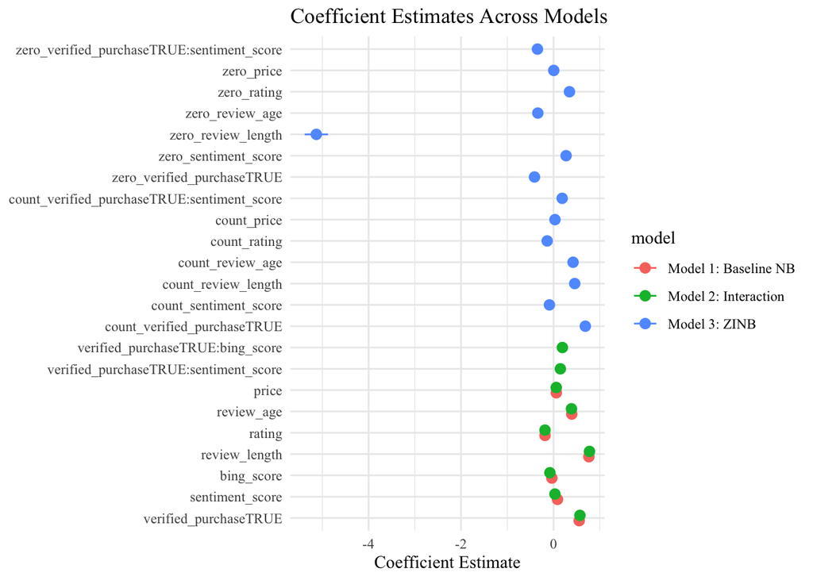

```r
models <- list(
  "Model 1: Baseline NB" = model1,
  "Model 2: Interaction" = model2,
  "Model 3: ZINB" = model_zinb
)

p <- modelplot(models,
               coef_omit = "(Intercept)|category",
               conf_level = 0.95) +  # bu argüman gerekli
  labs(title = "Coefficient Estimates Across Models",
       x = "Coefficient Estimate", y = NULL) +
  theme_minimal() +
  theme(text = element_text(family = "Times New Roman"))

print(p)
```

```r
models <- list(
  "Model 1: Baseline NB"     = model1,
  "Model 2: Verified × Sentiment" = model2,
  "Model 3: NRC Emotions"    = model3,
  "Model 4: Trust × Sentiment" = model5,
  "Model 5: BING Labels"     = model9,
  "Model 6: Moderated by Price" = model12,
  "Model 7: Minimal Model"  = model13,
  "ZINB Model"               = model_zinb
)

plot_obj <- modelplot(models,
          coef_omit = "(Intercept)|category",
          conf_level = 0.95) +
  labs(title = "Coefficient Estimates Across Models",
       x = "Coefficient Estimate", y = NULL) +
  theme_minimal() +
  theme(text = element_text(family = "Times New Roman"))


ggsave("model_comparison_plot2.png", plot = plot_obj,
       width = 10, height = 6, dpi = 300)
```

This code estimates separate Negative Binomial regression models for each product category to explore how the effects of predictors vary across different product types. Each model includes the same set of predictors which are verified purchase status, sentiment score, review length, review age, rating, and price allowing for consistent comparisons.

```r
categories <- unique(standardized_data$category)

models_by_category <- map(
  categories,
  ~ glm.nb(helpful_vote ~ verified_purchase + sentiment_score + review_length + review_age + rating + price,
           data = filter(standardized_data, category == .x))
)
names(models_by_category) <- categories

table_cat <- modelsummary(
  models_by_category,
  fmt = 3,
  stars = TRUE,
  statistic = "std.error",
  output = "flextable"
)


doc <- read_docx() %>%
  body_add_par("Table A3. Category-wise Negative Binomial Models", style = "heading 2") %>%
  body_add_flextable(table_cat) %>%
  body_add_par("Note: All continuous variables are z-standardized. Standard errors in parentheses. + p < 0.1, * p < 0.05, ** p < 0.01, *** p < 0.001", style = "Normal")

print(doc, target = "Table_A3_Category_Models.docx")
```